# Employment Case Study

```r
library(relaimpo)
library(MASS)
```

```r
numeric_predictors <- c("Age",
"t_DistanceFromHome",
"t_Education",
"t_EnvironmentSatisfaction",
"t_JobInvolvement",
"t_JobLevel",
"t_JobSatisfaction",
"t_NumCompaniesWorked",
"t_PercentSalaryHike",
"t_PerformanceRating",
"t_RelationshipSatisfaction",
"t_StockOptionLevel",
"t_TotalWorkingYears",
"t_TrainingTimesLastYear",
"t_WorkLifeBalance",
"t_YearsAtCompany",
"t_YearsInCurrentRole",
"t_YearsSinceLastPromotion",
"t_YearsWithCurrManager",
"numeric_OverTime",
"numeric_MaritalStatus")

factor_predictors <- c("BusinessTravel",
"Department",
"EducationField",
"Gender",
"JobRole",
"MaritalStatus")

all_predictors <- c(numeric_predictors,factor_predictors)

att_f_all <- as.formula(paste("numeric_attrition ~ ",
                             paste(all_predictors,collapse="+")))

att_f_num <- as.formula(paste("numeric_attrition ~ ",
                              paste(numeric_predictors,collapse="+")))

att_f_fac <- as.formula(paste("numeric_attrition ~ ",
                              paste(factor_predictors,collapse="+")))
```

```r
fit_nb <- lm(att_f_all, data=employee_data)
fit_nb$call
```

```
## lm(formula = att_f_all, data = employee_data)
```

```r
anova(fit_nb)
```

```
## Analysis of Variance Table
##
## Response: numeric_attrition
##                             Df Sum Sq Mean Sq F value    Pr(>F)
## Age                          1  2.621  2.6214 26.1453 3.935e-07 ***
## t_DistanceFromHome           1  0.785  0.7846  7.8256 0.0052705 **
## t_Education                  1  0.058  0.0580  0.5788 0.4470017
## t_EnvironmentSatisfaction    1  0.693  0.6931  6.9128 0.0087168 **
## t_JobInvolvement             1  4.027  4.0270 40.1642 3.829e-10 ***
## t_JobLevel                   1  1.393  1.3926 13.8896 0.0002070 ***
## t_JobSatisfaction            1  1.837  1.8370 18.3221 2.083e-05 ***
## t_NumCompaniesWorked         1  1.318  1.3177 13.1419 0.0003064 ***
## t_PercentSalaryHike          1  0.005  0.0047  0.0464 0.8295053
## t_PerformanceRating          1  0.002  0.0017  0.0172 0.8957885
## t_RelationshipSatisfaction   1  0.290  0.2904  2.8964 0.0891508 .
## t_StockOptionLevel           1  2.203  2.2031 21.9731 3.232e-06 ***
## t_TotalWorkingYears          1  2.055  2.0552 20.4978 6.844e-06 ***
## t_TrainingTimesLastYear      1  0.488  0.4877  4.8645 0.0276878 *
## t_WorkLifeBalance            1  0.614  0.6136  6.1199 0.0135661 *
## t_YearsAtCompany             1  0.094  0.0943  0.9402 0.3325063
## t_YearsInCurrentRole         1  0.170  0.1703  1.6987 0.1928134
## t_YearsSinceLastPromotion    1  2.091  2.0909 20.8541 5.708e-06 ***
## t_YearsWithCurrManager       1  0.158  0.1576  1.5715 0.2103484
## numeric_OverTime             1  7.561  7.5612 75.4136 < 2.2e-16 ***
## numeric_MaritalStatus        1  1.588  1.5881 15.8392 7.500e-05 ***
## BusinessTravel               2  0.823  0.4115  4.1044 0.0168357 *
## Department                   2  1.019  0.5093  5.0801 0.0064144 **
## EducationField               5  0.729  0.1457  1.4535 0.2027750
## Gender                       1  0.086  0.0861  0.8591 0.3542644
## JobRole                      8  1.607  0.2009  2.0041 0.0432948 *
## MaritalStatus                1  0.038  0.0383  0.3823 0.5365533
## Residuals                  829 83.119  0.1003
## ---
## Signif. codes:  0 '***' 0.001 '**' 0.01 '*' 0.05 '.' 0.1 ' ' 1
```

```r
stepwise_nb <- stepAIC(fit_nb,direction="both",trace=0)
stepwise_nb$call
```

```
## lm(formula = numeric_attrition ~ t_DistanceFromHome + t_EnvironmentSatisfaction +
##     t_JobInvolvement + t_JobSatisfaction + t_NumCompaniesWorked +
##     t_RelationshipSatisfaction + t_TotalWorkingYears + t_TrainingTimesLastYear +
##     t_WorkLifeBalance + t_YearsInCurrentRole + t_YearsSinceLastPromotion +
##     numeric_OverTime + BusinessTravel + JobRole + MaritalStatus,
##     data = employee_data)
```

```r
anova(stepwise_nb)
```

```
## Analysis of Variance Table
##
## Response: numeric_attrition
##                             Df Sum Sq Mean Sq F value    Pr(>F)
## t_DistanceFromHome           1  0.774  0.7743  7.7473 0.0054994 **
## t_EnvironmentSatisfaction    1  0.659  0.6592  6.5956 0.0103939 *
## t_JobInvolvement             1  4.160  4.1601 41.6256 1.860e-10 ***
## t_JobSatisfaction            1  1.608  1.6080 16.0898 6.576e-05 ***
## t_NumCompaniesWorked         1  0.363  0.3629  3.6307 0.0570636 .
## t_RelationshipSatisfaction   1  0.240  0.2404  2.4049 0.1213306
## t_TotalWorkingYears          1  7.246  7.2460 72.5021 < 2.2e-16 ***
## t_TrainingTimesLastYear      1  0.514  0.5143  5.1464 0.0235463 *
## t_WorkLifeBalance            1  0.700  0.6996  7.0002 0.0083015 **
## t_YearsInCurrentRole         1  0.303  0.3033  3.0347 0.0818651 .
## t_YearsSinceLastPromotion    1  2.120  2.1203 21.2153 4.736e-06 ***
## numeric_OverTime             1  7.557  7.5573 75.6164 < 2.2e-16 ***
## BusinessTravel               2  1.176  0.5878  5.8810 0.0029076 **
## JobRole                      8  3.096  0.3871  3.8728 0.0001699 ***
## MaritalStatus                2  2.503  1.2513 12.5204 4.380e-06 ***
## Residuals                  845 84.451  0.0999
## ---
## Signif. codes:  0 '***' 0.001 '**' 0.01 '*' 0.05 '.' 0.1 ' ' 1
```

```r
fit_knn <- lm(att_f_num, data=employee_data)
fit_knn$call
```

```
## lm(formula = att_f_num, data = employee_data)
```

```r
anova(fit_knn)
```

```
## Analysis of Variance Table
##
## Response: numeric_attrition
##                             Df Sum Sq Mean Sq F value    Pr(>F)
## Age                          1  2.621  2.6214 25.4283 5.616e-07 ***
## t_DistanceFromHome           1  0.785  0.7846  7.6110 0.0059263 **
## t_Education                  1  0.058  0.0580  0.5629 0.4532935
## t_EnvironmentSatisfaction    1  0.693  0.6931  6.7232 0.0096807 **
## t_JobInvolvement             1  4.027  4.0270 39.0628 6.493e-10 ***
## t_JobLevel                   1  1.393  1.3926 13.5087 0.0002524 ***
## t_JobSatisfaction            1  1.837  1.8370 17.8196 2.691e-05 ***
## t_NumCompaniesWorked         1  1.318  1.3177 12.7816 0.0003698 ***
## t_PercentSalaryHike          1  0.005  0.0047  0.0451 0.8318226
## t_PerformanceRating          1  0.002  0.0017  0.0167 0.8972185
## t_RelationshipSatisfaction   1  0.290  0.2904  2.8170 0.0936389 .
## t_StockOptionLevel           1  2.203  2.2031 21.3705 4.375e-06 ***
## t_TotalWorkingYears          1  2.055  2.0552 19.9357 9.092e-06 ***
## t_TrainingTimesLastYear      1  0.488  0.4877  4.7311 0.0298969 *
## t_WorkLifeBalance            1  0.614  0.6136  5.9521 0.0149039 *
## t_YearsAtCompany             1  0.094  0.0943  0.9144 0.3392148
## t_YearsInCurrentRole         1  0.170  0.1703  1.6522 0.1990154
## t_YearsSinceLastPromotion    1  2.091  2.0909 20.2822 7.617e-06 ***
## t_YearsWithCurrManager       1  0.158  0.1576  1.5284 0.2167001
## numeric_OverTime             1  7.561  7.5612 73.3455 < 2.2e-16 ***
## numeric_MaritalStatus        1  1.588  1.5881 15.4049 9.380e-05 ***
## Residuals                  848 87.421  0.1031
## ---
## Signif. codes:  0 '***' 0.001 '**' 0.01 '*' 0.05 '.' 0.1 ' ' 1
```

```r
stepwise_knn <- stepAIC(fit_knn,direction="both",trace=0)
stepwise_knn$call
```

```
## lm(formula = numeric_attrition ~ Age + t_DistanceFromHome + t_EnvironmentSatisfaction +
##     t_JobInvolvement + t_JobSatisfaction + t_NumCompaniesWorked +
##     t_RelationshipSatisfaction + t_TotalWorkingYears + t_TrainingTimesLastYear +
##     t_WorkLifeBalance + t_YearsInCurrentRole + t_YearsSinceLastPromotion +
##     t_YearsWithCurrManager + numeric_OverTime + numeric_MaritalStatus,
##     data = employee_data)
```

```r
anova(stepwise_knn)
```

```
## Analysis of Variance Table
##
## Response: numeric_attrition
##                             Df Sum Sq Mean Sq F value    Pr(>F)
## Age                          1  2.621  2.6214 25.5611 5.246e-07 ***
## t_DistanceFromHome           1  0.785  0.7846  7.6507 0.0057974 **
## t_EnvironmentSatisfaction    1  0.679  0.6787  6.6179 0.0102637 *
## t_JobInvolvement             1  4.055  4.0552 39.5417 5.120e-10 ***
## t_JobSatisfaction            1  1.697  1.6975 16.5518 5.172e-05 ***
## t_NumCompaniesWorked         1  1.274  1.2736 12.4183 0.0004477 ***
## t_RelationshipSatisfaction   1  0.278  0.2777  2.7076 0.1002413
## t_TotalWorkingYears          1  3.743  3.7431 36.4985 2.279e-09 ***
## t_TrainingTimesLastYear      1  0.525  0.5251  5.1200 0.0239015 *
## t_WorkLifeBalance            1  0.721  0.7207  7.0277 0.0081744 **
## t_YearsInCurrentRole         1  0.380  0.3804  3.7088 0.0544567 .
## t_YearsSinceLastPromotion    1  2.120  2.1202 20.6739 6.232e-06 ***
## t_YearsWithCurrManager       1  0.170  0.1696  1.6537 0.1988110
## numeric_OverTime             1  7.621  7.6211 74.3118 < 2.2e-16 ***
## numeric_MaritalStatus        1  3.220  3.2201 31.3991 2.835e-08 ***
## Residuals                  854 87.582  0.1026
## ---
## Signif. codes:  0 '***' 0.001 '**' 0.01 '*' 0.05 '.' 0.1 ' ' 1
```

# Predict Attrition with Naive Bayes classifier

```r
library(e1071)
library(caret)
```

## first determine the true percentage of Yes

```r
truth <- dplyr::count(employee_data,vars=Attrition)
num_yes <- as.numeric(truth[2,2])
num_no  <- as.numeric(truth[1,2])
num_obs <- num_yes + num_no
true_yes_perc <- round(100*num_yes/num_obs)
true_no_perc  <- round(100*num_no/num_obs)
```

True percentage of “yes” values is 16  
True percentage of “no” values is 84

```r
nb_laplace <- 1
nb_trials <- 100
train_frac <- 0.7
positive_value <- 'Yes'
# for repeatability
set.seed(42)
```

## First try all numeric variables

```r
#
nb_predictors <- c("Age",
                   "Education",
                   "BusinessTravel",
                   "Department",
                   "DistanceFromHome",
                   "EnvironmentSatisfaction",
                   "Gender",
                   "MonthlyIncome",
                   "NumCompaniesWorked",
                   "MaritalStatus",
                   "OverTime",
                   "PercentSalaryHike",
                   "PerformanceRating",
                   "TotalWorkingYears",
                   "TrainingTimesLastYear",
                   "WorkLifeBalance",
                   "YearsAtCompany",
                   "YearsSinceLastPromotion",
                   "YearsWithCurrManager"
                   )

# do the work
acc_nb <- matrix(nrow=nb_trials, ncol = 5)
nobs <- length(employee_data$Attrition)
for (j in 1:nb_trials)
{
  trainIndices <- sample(seq(1:nobs),round(train_frac*nobs))
  trainData <- employee_data[trainIndices,]
  testData <- employee_data[-trainIndices,]
  model_nb <- naiveBayes(trainData[,nb_predictors],trainData$Attrition)
  foo <- predict(model_nb,testData[,nb_predictors])
  tmp <- data.frame(foo)
  answers <- count(tmp,vars=foo)
  num_yes <- as.numeric(answers[2,2])
  num_no  <- as.numeric(answers[1,2])
  num_obs <- num_yes + num_no
  CM_nb <- confusionMatrix(table(predict(model_nb,testData[,nb_predictors]),
                                 testData$Attrition),positive=positive_value)
  acc_nb[j,1] <- CM_nb$overall[1] # accuracy
  acc_nb[j,2] <- CM_nb$byClass[1] # sensitivity
  acc_nb[j,3] <- CM_nb$byClass[2] # specificity
  acc_nb[j,4] <- num_yes / num_obs
  acc_nb[j,5] <- num_no / num_obs

}
mean_stats <- colMeans(acc_nb)
nb_acc <- mean_stats[1]
nb_sens <- mean_stats[2]
nb_spec <- mean_stats[3]
nb_yes_perc <- round(100*mean_stats[4])
nb_no_perc  <- round(100*mean_stats[5])
```

Averaging over 100 trials, the Naive Bayes classifier has

accuracy of 84 %

sensitivity of 42 %

specificity of 92 %

Average percentage of “yes” predictions is 13

Average percentage of “no” predictions is 87

## Subset the variables and try again

From stepwise variable selection, these are most important (in order)

```r
# predictors from stepwise AIC
nb_predictors_2 <- c("DistanceFromHome",
                   "EnvironmentSatisfaction",
                   "NumCompaniesWorked",
                   "OverTime",
                   "TotalWorkingYears",
                   "TrainingTimesLastYear",
                   "WorkLifeBalance",
                   "YearsSinceLastPromotion",
                   "JobInvolvement",
                   "JobSatisfaction",
                   "MaritalStatus"
                   )


# do the work
acc_nb <- matrix(nrow=nb_trials, ncol = 5)
nobs <- length(employee_data$Attrition)
for (j in 1:nb_trials)
{
  trainIndices <- sample(seq(1:nobs),round(train_frac*nobs))
  trainData <- employee_data[trainIndices,]
  testData <- employee_data[-trainIndices,]
  model_nb <- naiveBayes(trainData[,nb_predictors_2],trainData$Attrition)
  foo <- predict(model_nb,testData[,nb_predictors_2])
  tmp <- data.frame(foo)
  answers <- count(tmp,vars=foo)
  num_yes <- as.numeric(answers[2,2])
  num_no  <- as.numeric(answers[1,2])
  num_obs <- num_yes + num_no
  CM_nb <- confusionMatrix(table(predict(model_nb,testData[,nb_predictors_2]),
                                 testData$Attrition),positive=positive_value)
  acc_nb[j,1] <- CM_nb$overall[1] # accuracy
  acc_nb[j,2] <- CM_nb$byClass[1] # sensitivity
  acc_nb[j,3] <- CM_nb$byClass[2] # specificity
  acc_nb[j,4] <- num_yes / num_obs
  acc_nb[j,5] <- num_no / num_obs

}
mean_stats <- colMeans(acc_nb)
nb_acc <- mean_stats[1]
nb_sens <- mean_stats[2]
nb_spec <- mean_stats[3]
nb_yes_perc <- round(100*mean_stats[4])
nb_no_perc  <- round(100*mean_stats[5])
```

Averaging over 100 trials, the Naive Bayes classifier has

accuracy of 86 %

sensitivity of 26 %

specificity of 97 %

Average percentage of “yes” predictions is 6

Average percentage of “no” predictions is 94

## Naive Bayes does a moderately accurate job, but sensitivity is poor.

# Predict Attrition with K-nearest-neighbor algorithm.

## Define functions and select predictors

```r
library(caret)
library(class)
```

```r
# scale all numeric variables to normalize
# then select only the variable to be predicted and the normalized values
for_knn <- employee_data %>%
  dplyr::select(Attrition,
         z_DistanceFromHome,
         z_Education,
         z_EnvironmentSatisfaction,
         z_JobInvolvement,
         z_JobLevel,
         z_JobSatisfaction,
         z_NumCompaniesWorked,
         z_PercentSalaryHike,
         z_PerformanceRating,
         z_RelationshipSatisfaction,
         z_StockOptionLevel,
         z_TotalWorkingYears,
         z_TrainingTimesLastYear,
         z_WorkLifeBalance,
         z_YearsAtCompany,
         z_YearsInCurrentRole,
         z_YearsSinceLastPromotion,
         z_YearsWithCurrManager,
         z_OverTime,
         z_MaritalStatus)

yes_obs <- for_knn %>%
  filter(Attrition == 'Yes')

no_obs <- for_knn %>%
  filter(Attrition == 'No')

cols_for_knn <- c("z_DistanceFromHome",
                   "z_EnvironmentSatisfaction",
                   "z_NumCompaniesWorked",
                   "z_TotalWorkingYears",
                   "z_TrainingTimesLastYear",
                   "z_WorkLifeBalance",
                   "z_YearsSinceLastPromotion",
                   "z_JobInvolvement",
                   "z_JobSatisfaction")

#                   "z_MaritalStatus",
#                   "z_OverTime")

# adjust the knn results by known probabilities
knn_adjust <- function(orig_factor, k, num_no=1, num_yes=1)
{
  # What was original answer
  orig_answer <- as.character(orig_factor)
  other_answer <- ifelse(orig_answer == 'No','Yes','No')

  # original probabilities
  orig_win    <- attr(orig_factor,'prob')
  orig_lose   <- 1.0 - orig_win

  # determine how many votes for winner and loser
  win_votes <- k * orig_win
  lose_votes <- k - win_votes

  # the next two statements normalize votes
  # by the total available no or yes observations

  # if the original answer was no, then divide win by total number of no's
  win  <- win_votes  / ifelse (orig_answer == 'No', num_no, num_yes)

  # if the original answer was yes, then loser was 'no' ...
  lose <- lose_votes / ifelse (orig_answer == 'Yes',num_no, num_yes)

  # alter the answer if lose > win
  new_answer <- as.factor(ifelse( (lose > win), other_answer, orig_answer))

  #cat('--- rmp debug ---')
  #cat(' k          ',k,'\n')
  #cat(' num_no     ',num_no,'\n')
  #cat(' num_yes    ',num_yes,'\n')
  #cat(' orig_answer',orig_answer,'\n')
  #cat(' orig_win   ',orig_win,'\n')
  #cat(' win_votes  ',win_votes,'\n')
  #cat(' (new) win  ',win,'\n')
  #cat(' (new) lose ',lose,'\n')
  #cat(' new_answer ',new_answer,'\n')

  levels(new_answer) <- levels(orig_factor)
  return(new_answer)
}
```

## What is the expected outcome?

```r
summary(for_knn$Attrition)
```

```
##  No Yes
## 730 140
```

```r
truth <- dplyr::count(employee_data,vars=Attrition)
truth.yes <- as.numeric(truth[2,2])
truth.no  <- as.numeric(truth[1,2])
truth.nobs <- truth.yes + truth.no
true_yes_perc <- round(100*truth.yes/truth.nobs)
true_no_perc  <- round(100*truth.no/truth.nobs)
```

True percentage of “yes” values is 16  
True percentage of “no” values is 84

## Set parameters for KNN

```r
set.seed(42)
train_frac <- 0.7
numks <- 50
knn_trials <- 100
positive_value <- 'Yes'
max_acc_k = 10
chosen_k = 5
```

## Select K

run KNN with different values of K to select appropriate neighborhood size.

```r
# look for the best value of k
#  do several trials, and for each trial
#   split data into training and test
#   make classifier and from the confusion matrix,
#   save the accuracy, sensitivity, and specificity
knn_stats = matrix(nrow=numks,ncol=6)
true_pcyes <- truth.yes/truth.nobs
for (i in 1:numks)
{
  acc  = matrix(nrow=knn_trials,ncol=1)
  sens = matrix(nrow=knn_trials,ncol=1)
  spec = matrix(nrow=knn_trials,ncol=1)
  pcyes = matrix(nrow=knn_trials,ncol=1)
  pcno  = matrix(nrow=knn_trials,ncol=1)
  for (j in 1:knn_trials)
  {
    # extract equal 'Yes' and 'No' subsets, put together into one set, which
    # will then be split into training and test parts
    cnt <- min(truth.yes,truth.no)
    trial_space <- rbind(sample_n(yes_obs,cnt,replace=FALSE),sample_n(no_obs,cnt,replace=FALSE))

    trainIndices = sample(1:dim(trial_space)[1],round(train_frac * dim(trial_space)[1]))
    trainData = trial_space[trainIndices,]
    testData = trial_space[-trainIndices,]
    raw_class = knn(trainData[,cols_for_knn],
                              testData[,cols_for_knn],
                              trainData$Attrition, prob = TRUE, k = i)

    # with the equal sampling, there should be no need to normalize
    # classifications = knn_adjust(raw_class, k = i, num_no = truth.no, num_yes = truth.yes)
    classifications <- raw_class
    tmp <- data.frame(classifications)
    answers <- count(tmp,vars=classifications)

    num_yes <- as.numeric(answers[2,2])
    num_no  <- as.numeric(answers[1,2])
    num_obs <- num_yes + num_no

    CM = confusionMatrix(table(testData$Attrition,classifications),positive=positive_value)
    acc[j]  = CM$overall[1]
    sens[j] = CM$byClass[1]
    spec[j] = CM$byClass[2]
    pcyes[j] = num_yes / num_obs
    pcno[j]  = num_no / num_obs
  }

  # make a matrix with accuracy, sensitivity, and specificity
  knn_stats[i,1] = i
  knn_stats[i,2] = colMeans(acc,na.rm = TRUE)
  knn_stats[i,3] = colMeans(sens,na.rm = TRUE)
  knn_stats[i,4] = colMeans(spec,na.rm = TRUE)
  knn_stats[i,5] = colMeans(pcyes,na.rm = TRUE)
  knn_stats[i,6] = colMeans(pcno,na.rm = TRUE)
}
```

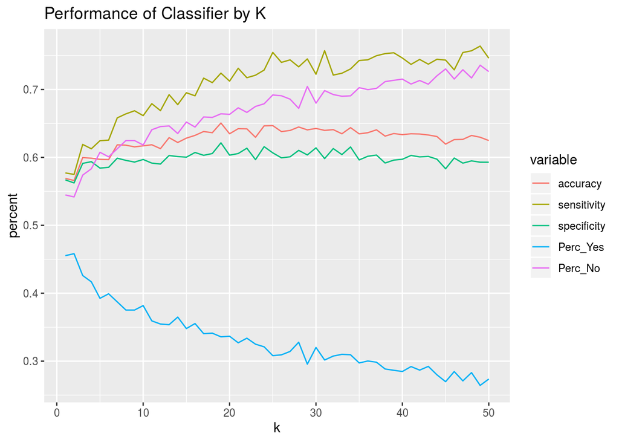

```r
stats_frame <- data.frame(knn_stats)
colnames(stats_frame) <- c("k","accuracy","sensitivity","specificity","Perc_Yes","Perc_No")
for_plot <- reshape2::melt(stats_frame,id.var='k')
for_plot %>% ggplot(aes(x=k,y=value,col=variable)) +
  geom_line() +
  xlab('k') +
  ylab('percent') +
  ggtitle('Performance of Classifier by K')
```

```r
combined_stats <- stats_frame %>%
  mutate(sums = accuracy + sensitivity + specificity)

max_acc_k <- which.max(knn_stats[,2])
chosen_k  <- max_acc_k
#chosen_k <-  5

chosen_acc  <- round(100*combined_stats$accuracy[chosen_k])
chosen_sens <- round(100*combined_stats$sensitivity[chosen_k])
chosen_spec <- round(100*combined_stats$specificity[chosen_k])
```

## Select K

max accuracy is at k = 19.  
Although k of 19 provides the highest accuracy, we choose k of 19, because higher and higher k values result in worse specificity.

At that k, we have  
accuracy of 65  
sensitivity of 72  
specificity of 62

```r
rm(knn_stats)
rm(combined_stats)
rm(acc)
rm(sens)
rm(spec)
rm(pcyes)
rm(pcno)
rm(score)
gc()
```

```
##           used  (Mb) gc trigger  (Mb) max used  (Mb)
## Ncells 2428459 129.7    5331254 284.8  5331254 284.8
## Vcells 4399354  33.6   14786712 112.9 14786323 112.9
```

## Repeat classifictiton on entire dataset

```r
# make a new classifier using all the data
knn_pred <- knn(for_knn[,cols_for_knn],
                for_knn[,cols_for_knn],
                for_knn$Attrition,k=chosen_k)
CM_knn = confusionMatrix(table(as.factor(for_knn$Attrition),knn_pred),positive=positive_value)
knn_acc <- CM_knn$overall[1] # accuracy
knn_sens <- CM_knn$byClass[1] # sensitivity
knn_spec <- CM_knn$byClass[2] # specificity

tmp <- data.frame(knn_pred)
answers <- count(tmp,vars=knn_pred)
num_yes <- as.numeric(answers[2,2])
num_no  <- as.numeric(answers[1,2])
num_obs <- num_yes + num_no
perc_yes <- round(100*num_yes/num_obs)
perc_no  <- round(100*num_no/num_obs)
```

Using the entire dataset,

KNN accuracy turns out to be 84 %.

KNN sensitivity is 100 %.

KNN specificity is 84 %.

## Predict with KNN

Since the KNN classifier does a better job of predicting Attrition, we will use it for making predictions on the unlabeled data for submission.

```r
# read in the blind test dataset

blind_raw <- read.csv('CaseStudy2CompSetNoAttrition.csv')
blind_test <- my_transform(blind_raw)

if (FALSE) {
  predicted_attrition <- as.factor(knn(for_knn[,cols_for_knn],
                           blind_test[,cols_for_knn],
                           for_knn$Attrition,k=chosen_k))
  str(predicted_attrition)
  summary(predicted_attrition)
} else {
  # rmp try adjusting blind results
  raw_class = as.factor(knn(for_knn[,cols_for_knn],
                          blind_test[,cols_for_knn],
                          for_knn$Attrition,prob=TRUE,k=chosen_k))
  levels(raw_class) <- c("No","Yes")

  str(raw_class)
  summary(raw_class)

  predicted_attrition = knn_adjust(raw_class, k = chosen_k, num_no = truth.no, num_yes = truth.yes)
  str(predicted_attrition)
  summary(predicted_attrition)
}
```

```
##  Factor w/ 2 levels "No","Yes": 1 1 1 1 1 1 1 1 1 1 ...
##  - attr(*, "prob")= num [1:300] 0.842 1 0.737 1 0.947 ...
##  Factor w/ 2 levels "No","Yes": 1 1 2 1 1 2 2 1 1 2 ...
```

```
##  No Yes
## 228  72
```

```r
summary(predicted_attrition)
```

```
##  No Yes
## 228  72
```

```r
for_submission <- cbind(blind_test$ID,as.character(predicted_attrition))
colnames(for_submission) <- c("ID","Attrition")
write.csv(for_submission,file="Case2PredictionsPalmerAttrition.csv",row.names=FALSE,quote=FALSE)
```

```r
all_numeric <- c("Age",
"t_DistanceFromHome",
"t_Education",
"t_EnvironmentSatisfaction",
"t_JobInvolvement",
"t_JobLevel",
"t_JobSatisfaction",
"t_NumCompaniesWorked",
"t_PercentSalaryHike",
"t_PerformanceRating",
"t_RelationshipSatisfaction",
"t_StockOptionLevel",
"t_TotalWorkingYears",
"t_TrainingTimesLastYear",
"t_WorkLifeBalance",
"t_YearsAtCompany",
"t_YearsInCurrentRole",
"t_YearsSinceLastPromotion",
"t_YearsWithCurrManager",
"numeric_MaritalStatus",
"numeric_OverTime")

all_factors <- c("BusinessTravel",
"Department",
"EducationField",
"Gender",
"JobRole",
"MaritalStatus")


stepwise_factors <- c("BusinessTravel",
"Gender",
"JobRole")
stepwise_numeric <- c("t_DistanceFromHome",
"t_JobLevel",
"t_PercentSalaryHike",
"t_PerformanceRating",
"t_TotalWorkingYears",
"t_YearsSinceLastPromotion",
"t_YearsWithCurrManager")


subjective_factors <- c("Gender",
"JobRole",
"EducationField")
subjective_numeric <- c("t_JobLevel",
"t_TotalWorkingYears",
"t_Education",
"t_PerformanceRating",
"t_RelationshipSatisfaction",
"t_StockOptionLevel",
"t_YearsAtCompany")


mi_f_stepwise   <- as.formula(paste("t_MonthlyIncome ~ ",
                             paste(stepwise_numeric,collapse="+")))

mi_f_creosote   <- as.formula(paste("t_MonthlyIncome ~ ",
                             paste(all_numeric,collapse="+")))

mi_f_subjective <- as.formula(paste("t_MonthlyIncome ~ ",
                             paste(subjective_numeric,collapse="+")))


train_control <- trainControl(method="LOOCV")
```

```r
make_qc <- function(model)
{
  df <- employee_data
  df$predicted <- exp(model$fitted.values)
  df$residuals <- model$residuals
  return(df)
}

qc_plots <- function(qc,label)
{
  ggplot(qc, aes(x=residuals)) + geom_histogram() + ggtitle(paste("Histograme of ",label,"residuals"))
  ggplot(qc, aes(x=MonthlyIncome,y=predicted)) + geom_point() + ggtitle(paste("predicted versus actual for ",label))
  ggplot(qc, aes(sample=residuals)) + stat_qq() + ggtitle(paste("QQ of residuals for",label))
}
```

```r
########################### stepwise ###################################

# stepwise
stepwise_loocv <- train(mi_f_stepwise,
                      data=employee_data,
                      method="lm",trControl = train_control)
print(stepwise_loocv)
```

```
## Linear Regression
##
## 870 samples
##   7 predictor
##
## No pre-processing
## Resampling: Leave-One-Out Cross-Validation
## Summary of sample sizes: 869, 869, 869, 869, 869, 869, ...
## Resampling results:
##
##   RMSE       Rsquared   MAE
##   0.2480259  0.8592698  0.1933345
##
## Tuning parameter 'intercept' was held constant at a value of TRUE
```

```r
stepwise_r2 <- stepwise_loocv$results$Rsquared
stepwise_model <- stepwise_loocv$finalModel
summary(stepwise_model)
```

```
##
## Call:
## lm(formula = .outcome ~ ., data = dat)
##
## Residuals:
##      Min       1Q   Median       3Q      Max
## -1.00863 -0.16117  0.01689  0.15368  0.75716
##
## Coefficients:
##                            Estimate Std. Error t value Pr(>|t|)
## (Intercept)                7.349211   0.087032  84.443  < 2e-16 ***
## t_DistanceFromHome        -0.001280   0.006316  -0.203  0.83951
## t_JobLevel                 0.494594   0.011680  42.346  < 2e-16 ***
## t_PercentSalaryHike        0.004829   0.003622   1.333  0.18279
## t_PerformanceRating       -0.053046   0.036988  -1.434  0.15189
## t_TotalWorkingYears        0.078465   0.012173   6.446 1.91e-10 ***
## t_YearsSinceLastPromotion -0.016872   0.012410  -1.360  0.17434
## t_YearsWithCurrManager     0.033710   0.012526   2.691  0.00726 **
## ---
## Signif. codes:  0 '***' 0.001 '**' 0.01 '*' 0.05 '.' 0.1 ' ' 1
##
## Residual standard error: 0.2468 on 862 degrees of freedom
## Multiple R-squared:  0.8619, Adjusted R-squared:  0.8608
## F-statistic: 768.6 on 7 and 862 DF,  p-value: < 2.2e-16
```

```r
stepwise_qc <- make_qc(stepwise_model)
```

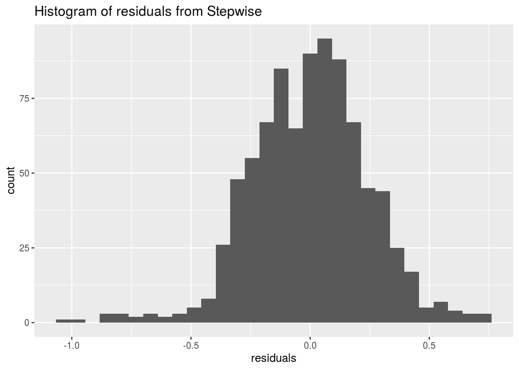

```r
ggplot(stepwise_qc, aes(x=residuals)) +
  geom_histogram() +
  ggtitle(paste("Histogram of residuals from Stepwise"))
```

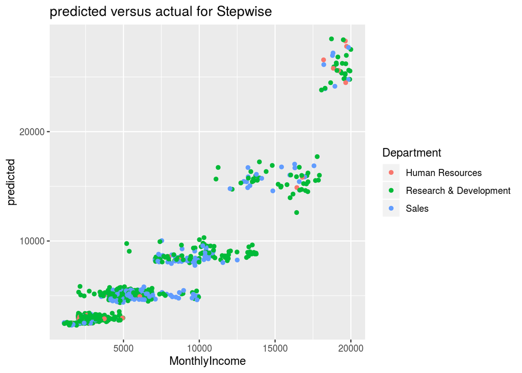

```r
ggplot(stepwise_qc, aes(x=MonthlyIncome,y=predicted,col=Department)) +
  geom_point() +
  ggtitle(paste("predicted versus actual for Stepwise"))
```

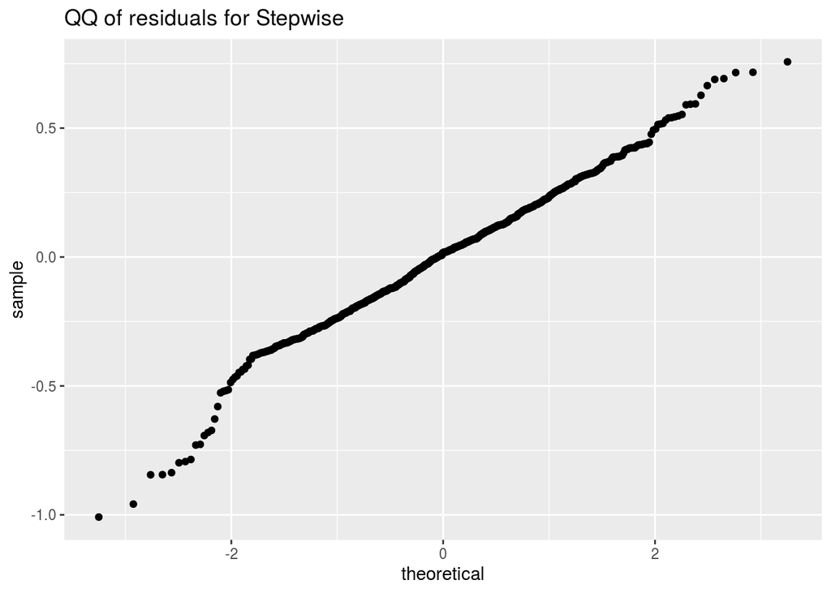

```r
ggplot(stepwise_qc, aes(sample=residuals)) +
  stat_qq() +
  ggtitle(paste("QQ of residuals for Stepwise"))
```

```r
rm(stepwise_loocv)
#rm(stepwise_model)
rm(stepwise_qc)
gc()
```

```
##           used  (Mb) gc trigger  (Mb) max used  (Mb)
## Ncells 2554094 136.5    5331254 284.8  5331254 284.8
## Vcells 5021988  38.4   14786712 112.9 14786694 112.9
```

```r
########################### subjective ###################################

# subjectively chosen predictors
subjective_loocv <- train(mi_f_subjective,
                      data=employee_data,
                      method="lm",trControl = train_control)
print(subjective_loocv)
```

```
## Linear Regression
##
## 870 samples
##   7 predictor
##
## No pre-processing
## Resampling: Leave-One-Out Cross-Validation
## Summary of sample sizes: 869, 869, 869, 869, 869, 869, ...
## Resampling results:
##
##   RMSE       Rsquared   MAE
##   0.2483297  0.8589251  0.1930428
##
## Tuning parameter 'intercept' was held constant at a value of TRUE
```

```r
subjective_r2 <- subjective_loocv$results$Rsquared
subjective_model <- subjective_loocv$finalModel
summary(subjective_model)
```

```
##
## Call:
## lm(formula = .outcome ~ ., data = dat)
##
## Residuals:
##      Min       1Q   Median       3Q      Max
## -0.98395 -0.16379  0.00752  0.15735  0.76925
##
## Coefficients:
##                             Estimate Std. Error t value Pr(>|t|)
## (Intercept)                 7.292362   0.085465  85.326  < 2e-16 ***
## t_JobLevel                  0.493061   0.011669  42.252  < 2e-16 ***
## t_TotalWorkingYears         0.073775   0.012559   5.874 6.07e-09 ***
## t_Education                 0.010348   0.008325   1.243   0.2142
## t_PerformanceRating        -0.013623   0.023395  -0.582   0.5605
## t_RelationshipSatisfaction -0.009698   0.007620  -1.273   0.2034
## t_StockOptionLevel          0.007264   0.009800   0.741   0.4587
## t_YearsAtCompany            0.023803   0.013542   1.758   0.0791 .
## ---
## Signif. codes:  0 '***' 0.001 '**' 0.01 '*' 0.05 '.' 0.1 ' ' 1
##
## Residual standard error: 0.2471 on 862 degrees of freedom
## Multiple R-squared:  0.8616, Adjusted R-squared:  0.8605
## F-statistic: 766.6 on 7 and 862 DF,  p-value: < 2.2e-16
```

```r
subjective_qc <- make_qc(subjective_model)
```

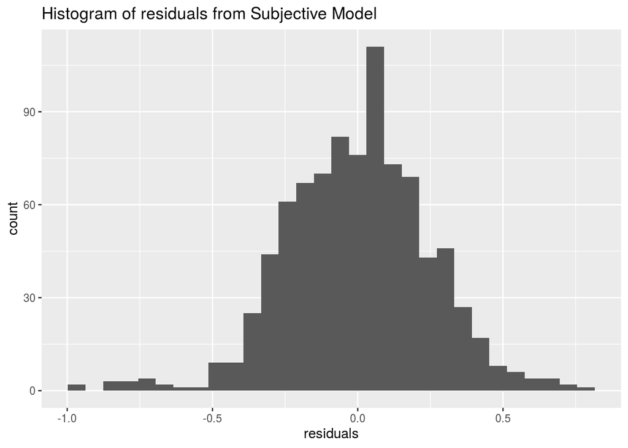

```r
ggplot(subjective_qc, aes(x=residuals)) +
  geom_histogram() +
  ggtitle(paste("Histogram of residuals from Subjective Model"))
```

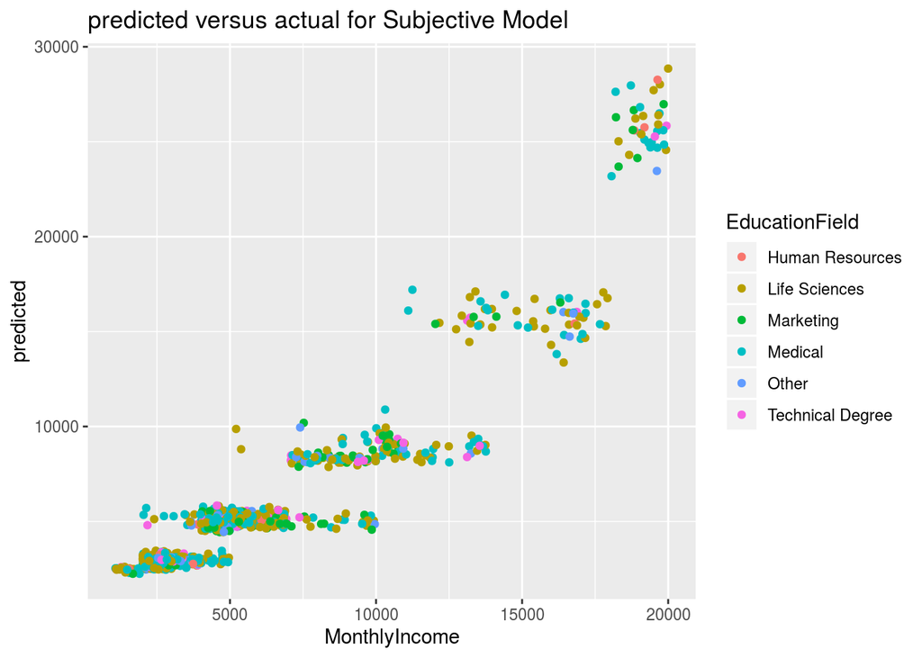

```r
ggplot(subjective_qc, aes(x=MonthlyIncome,y=predicted,color=EducationField)) +
  geom_point() +
  ggtitle(paste("predicted versus actual for Subjective Model"))
```

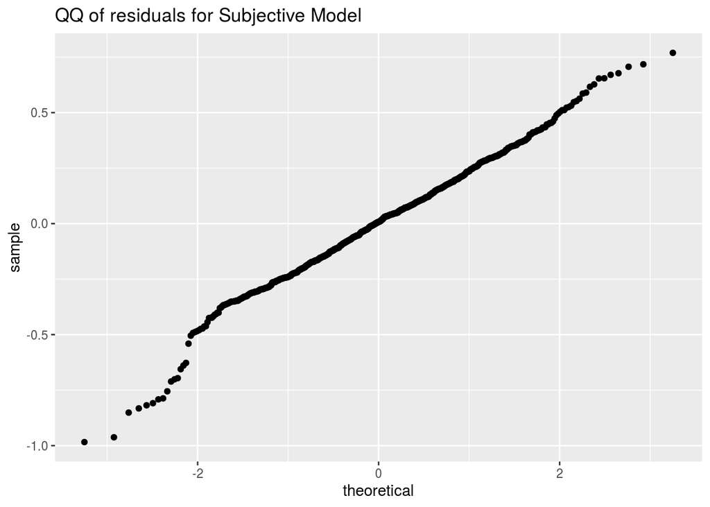

```r
ggplot(subjective_qc, aes(sample=residuals)) +
  stat_qq() +
  ggtitle(paste("QQ of residuals for Subjective Model"))
```

```r
rm(subjective_loocv)
#rm(subjective_model)
rm(subjective_qc)
gc()
```

```
##           used  (Mb) gc trigger  (Mb) max used  (Mb)
## Ncells 2558030 136.7    5331254 284.8  5331254 284.8
## Vcells 5465562  41.7   14786712 112.9 14786709 112.9
```

```r
reprise_raw <- read.csv('CaseStudy2-data.csv')
reprise_test <- my_transform(reprise_raw)
subjective_sanity <- exp(predict(subjective_model, newdata = reprise_test))
stepwise_sanity   <- exp(predict(stepwise_model, newdata = reprise_test))
```

```r
# read in the blind test dataset

blind_raw <- read.csv('CaseStudy2CompSetNoSalary.csv')
blind_test <- my_transform(blind_raw)
predicted_salary <- exp(predict(stepwise_model,newdata=blind_test))

for_submission <- cbind(blind_test$ID,predicted_salary)
colnames(for_submission) <- c("ID","Salary")
write.csv(for_submission,file="Case2PredictionsPalmerSalary.csv",row.names=FALSE,quote=FALSE)
```